# Ahmet KIRAN

2026-05-02

# 1. TGSS2024 Anket Verileri

Bu veri seti sav formatında olup 2615 satır ve 674 değişken içeren gözlemlerden oluşmaktadır. TGSS,Türkiye’deki genç nüfusun sosyal, ekonomik ve kültürel eğilimlerini anlamak amacıyla yürütülen bir çalışmadır.Bu paylaşım, R Studio platformunda bir veri setinin analiz sürecinde tidyverse, foreign ve haven başta olmak üzere kullanılan kütüphane ve kodları içermektedir.Bir alıştırma uygulaması olmasının yanı sıra toplumdaki cinsiyet, fırsat eşitliği ve istihdam arasındaki ilişkileri analiz etme amacı güdülmüştür.

# 2. Verinin Yüklenmesi, Temizlik ve Kütüphaneler

Veri setimiz R’nin default kütüphanesindeki kodlar ile okunmadığından ilk olarak kütüphanelerimizi kuruyoruz.

```r
library(haven)
library(tidyverse)
library(foreign)
library(doParallel)
corenum <- detectCores() - 1
doParallel::registerDoParallel(corenum)
setwd("~/AllProjects/R_ile_veri_analizi")
tgss <- read.spss("TGSS2024.sav", to.data.frame = TRUE)
```

Veri setimiz çok büyük olduğu için analizimiz için kullanacağımız değişkenleri ele alalım ve NA değerlerini verimizden kaldıralım.(Bu çalışmada bir satırda bile NA değeri varsa o satırdaki veriyi örneklemimizden çıkardık.Kullanacağımız satırlarda NA değerlerinin bulunup bulunmadığına göre filtreleyip örneklemi daha büyük olacak şekilde de kullanabilirdik.)

```r
data <- tgss %>%
select(empstat,gender,educ,age,degurba,marital)

data_temiz <- data %>%
drop_na()
```

Seçtiğimiz değişkenler faktörlere ayrılmış veriler olduğu için bu verileri kendi dilimize göre sınıflandırmak için ordered fonksiyonunu kullanacağız.Bazı değişkenler çok fazla faktöre sahip olduğundan tek bir başlık altında toplandı.

```r
levels(data_temiz$empstat)
```

```
## [1] "Gelir getiren bir işte çalışıyor (veya şu an geçici olarak uzakta) (Örneğin; işçi, kendi işinde çalışan,"
## [2] "Öğrenci (tatilde de olsa)"
## [3] "İşsiz ve aktif olarak iş arıyor"
## [4] "İşsiz, iş istiyor ama aktif olarak iş aramıyor"
## [5] "Kalıcı olarak hasta ya da engelli"
## [6] "Emekli"
## [7] "Zorunlu askerlik görevinde"
## [8] "Ev işleri yapıyor, çocuklara veya diğer kişilere bakıyor"
## [9] "Diğer"
```

```r
levels(data_temiz$gender)
```

```
## [1] "Erkek" "Kadın"
```

```r
levels(data_temiz$educ)
```

```
## [1] "Herhangi bir okul bitirmedim"
## [2] "İlkokul"
## [3] "Ortaokul / İlköğretim"
## [4] "Lise"
## [5] "2 veya 3 yıllık meslek yüksekokulu"
## [6] "4-5-6 yıllık fakülte / 4 yıllık yüksekokulu"
## [7] "Yüksek lisans"
## [8] "Doktora"
```

```r
levels(data_temiz$age)
```

```
##  [1] "15"                     "16"                     "17"
##  [4] "18"                     "19"                     "20"
##  [7] "21"                     "22"                     "23"
## [10] "24"                     "25"                     "26"
## [13] "27"                     "28"                     "29"
## [16] "30"                     "31"                     "32"
## [19] "33"                     "34"                     "35"
## [22] "36"                     "37"                     "38"
## [25] "39"                     "40"                     "41"
## [28] "42"                     "43"                     "44"
## [31] "45"                     "46"                     "47"
## [34] "48"                     "49"                     "50"
## [37] "51"                     "52"                     "53"
## [40] "54"                     "55"                     "56"
## [43] "57"                     "58"                     "59"
## [46] "60"                     "61"                     "62"
## [49] "63"                     "64"                     "65"
## [52] "66"                     "67"                     "68"
## [55] "69"                     "70"                     "71"
## [58] "72"                     "73"                     "74"
## [61] "75"                     "76"                     "77"
## [64] "78"                     "79"                     "80"
## [67] "81"                     "82"                     "83"
## [70] "84"                     "85"                     "86"
## [73] "87"                     "88"                     "89"
## [76] "90"                     "91"                     "92"
## [79] "93"                     "94"                     "95"
## [82] "96"                     "97"                     "98"
## [85] "99"                     "100 years old or older"
```

```r
levels(data_temiz$degurba)
```

```
## [1] "Kırsal"          "Orta Yoğun Kent" "Yoğun Kent"
```

```r
levels(data_temiz$marital)
```

```
## [1] "Hiç evlenmedi"                    "Evli, eşiyle birlikte yaşıyor"
## [3] "Evli, eşiyle birlikte yaşamıyor"  "Evli değil, ama birlikte yaşıyor"
## [5] "Boşandı"                          "Eşi öldü"
```

```r
levels(data_temiz$empstat) <- c(
"Calisiyor","Ogrenci","Calismiyor","Calismiyor","Hasta/Engelli","Emekli","Asker","Calismiyor","Diger")

levels(data_temiz$educ) <-  c(
  "Yok","Ilkokul","Ortaokul","Lise","Onlisans","Lisans","LisansUstu","Doktora")

data_temiz$educ <-  ordered(data_temiz$educ, levels = c("Yok","Ilkokul","Ortaokul","Lise","Onlisans","Lisans","LisansUstu","Doktora"))

#Yaş değerlerimizi faktörlerden değerlere dönüştürüp ardından aralıklara bölüyoruz.
#Bunun nedeni çalışma oranlarının yaş aralıklarına göre dağılımını inceleyecek olmamız.
data_temiz$age <- as.numeric(as.character(data_temiz$age))
data_temiz$age <- cut(data_temiz$age, breaks = c(14,24,44,64,120), labels = c("15-24","25-44","45-64","65+"))

levels(data_temiz$degurba) <- c("Kirsal","OrtaYogunKent","YogunKent")

levels(data_temiz$marital) <- c("Bekar","Evli","Evli","Bekar","Bosandi","Dul")
```

#3.Tek-İki Değişkenli Görseller ve Çıkarımlar

Bu kısımda düzenlediğimiz ve temizlediğimiz veri setinin dağılımlarını ggplot2 kütüphanesi yardımıyla grafiklere ve görselliğe dökeceğiz.

```
## Erkek Kadın
##   197   202
```

```
## 15-24 25-44 45-64   65+
##    73   159   139    28
```

```
##   Bekar    Evli Bosandi     Dul
##     113     257      16      13
```

```
##        Kirsal OrtaYogunKent     YogunKent
##            64            42           293
```

```
##        Yok    Ilkokul   Ortaokul       Lise   Onlisans     Lisans LisansUstu
##         12         65         56        142         33         75         12
##    Doktora
##          4
```

##Cinsiyete Göre İstihdam Durum Grafiği

Bu grafikte erkek ve kadınların çalışma durumlarını inceliyor olacağız ve görmüş olacağız ki çalışmayan kadınların sayısı erkeklere oranla bir hayli yüksek. Sayıları küçük kod bloğu aracılığıyla görebiliriz.

```r
data_temiz %>%
count(gender,empstat)
```

```
##    gender       empstat   n
## 1   Erkek     Calisiyor  94
## 2   Erkek       Ogrenci  23
## 3   Erkek    Calismiyor  23
## 4   Erkek Hasta/Engelli   2
## 5   Erkek        Emekli  43
## 6   Erkek         Diger  12
## 7   Kadın     Calisiyor  54
## 8   Kadın       Ogrenci  21
## 9   Kadın    Calismiyor 104
## 10  Kadın Hasta/Engelli   1
## 11  Kadın        Emekli  12
## 12  Kadın         Diger  10
```

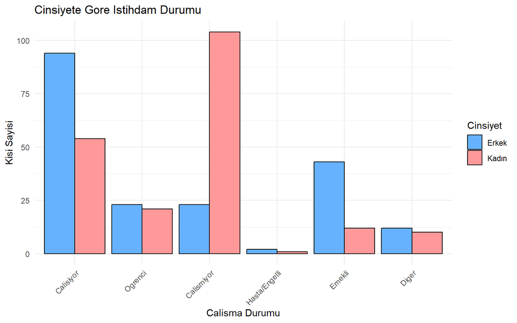

```r
ggplot(data = data_temiz, aes(x = empstat, fill = gender)) +
  geom_bar(position = "dodge", color = "black") +
  scale_fill_manual(values = c("Kadın" = "#FF9999", "Erkek" = "#66B2FF")) +
  theme_minimal() +
  labs(title = "Cinsiyete Gore Istihdam Durumu",
       x = "Calisma Durumu",
       y = "Kisi Sayisi",
       fill = "Cinsiyet") +
    theme(axis.text.x = element_text(angle = 45, hjust = 1))
```

## Eğitim Seviyesine Göre Çalışma Dağılım Grafiği

Burada eğitim düzeylerinin cinsiyete göre dağılımını görüyor ve ardından da eğitim seviyesine bağlı olarak cinsiyete göre çalışma dağılımını inceliyor olacağız.

```r
data_temiz %>%
  count(educ,gender)
```

```
##          educ gender  n
## 1         Yok  Erkek  2
## 2         Yok  Kadın 10
## 3     Ilkokul  Erkek 41
## 4     Ilkokul  Kadın 24
## 5    Ortaokul  Erkek 28
## 6    Ortaokul  Kadın 28
## 7        Lise  Erkek 68
## 8        Lise  Kadın 74
## 9    Onlisans  Erkek 17
## 10   Onlisans  Kadın 16
## 11     Lisans  Erkek 33
## 12     Lisans  Kadın 42
## 13 LisansUstu  Erkek  6
## 14 LisansUstu  Kadın  6
## 15    Doktora  Erkek  2
## 16    Doktora  Kadın  2
```

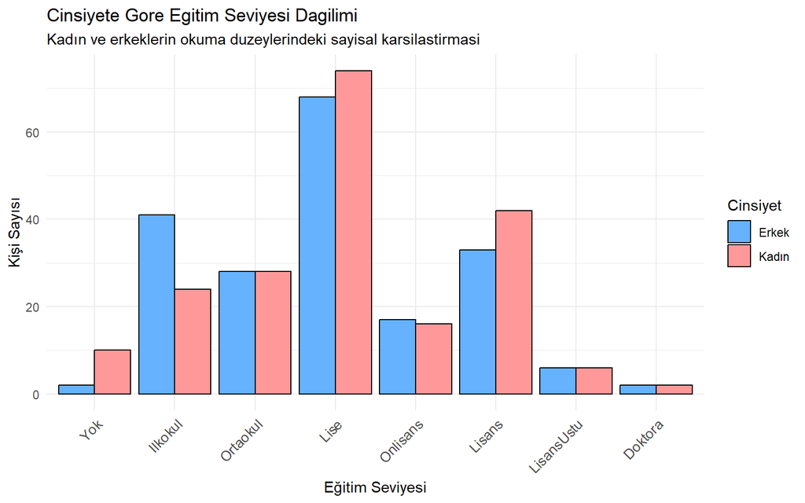

```r
ggplot(data = data_temiz, aes(x = educ, fill = gender)) +
  geom_bar(position = "dodge", color = "black") +
  scale_fill_manual(values = c("Kadın" = "#FF9999", "Erkek" = "#66B2FF")) +
  theme_minimal() +
  labs(title = "Cinsiyete Gore Egitim Seviyesi Dagilimi",
       subtitle = "Kadın ve erkeklerin okuma duzeylerindeki sayisal karsilastirmasi",
       x = "Eğitim Seviyesi",
       y = "Kişi Sayısı",
       fill = "Cinsiyet") +
  theme(axis.text.x = element_text(angle = 45, hjust = 1, size = 10))
```

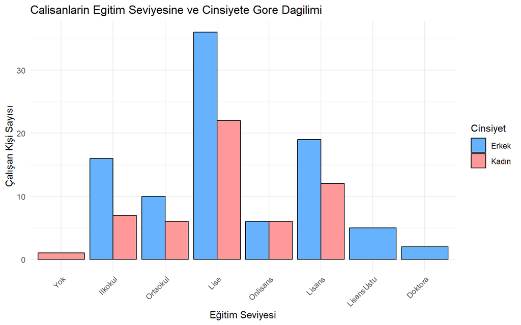

```r
data_temiz %>%
  filter(empstat == "Calisiyor") %>%
  ggplot(aes(x = educ, fill = gender)) +
  geom_bar(position = "dodge", color = "black") +
  scale_fill_manual(values = c("Kadın" = "#FF9999", "Erkek" = "#66B2FF")) +
  theme_minimal() +
  labs(title = "Calisanlarin Egitim Seviyesine ve Cinsiyete Gore Dagilimi",
       x = "Eğitim Seviyesi",
       y = "Çalışan Kişi Sayısı",
       fill = "Cinsiyet") +
  theme(axis.text.x = element_text(angle = 45, hjust = 1))
```

##Çalışanların Medeni Durum ve Cinsiyete Göre Dağılım Grafiği

Bu kısımda çalışan kişilerin cinsiyetlere dağılımını gösteriyor olacağız.

```r
data_temiz %>%
  filter(empstat == "Calisiyor") %>%
  count(marital,gender)
```

```
##   marital gender  n
## 1   Bekar  Erkek 22
## 2   Bekar  Kadın 16
## 3    Evli  Erkek 69
## 4    Evli  Kadın 33
## 5 Bosandi  Erkek  2
## 6 Bosandi  Kadın  2
## 7     Dul  Erkek  1
## 8     Dul  Kadın  3
```

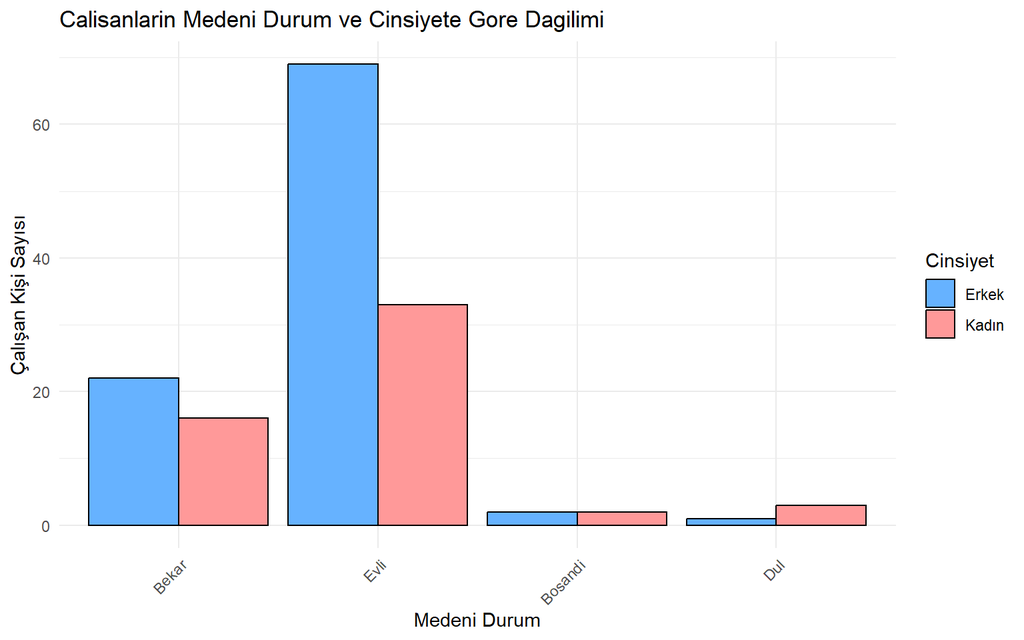

```r
data_temiz %>%
  filter(empstat == "Calisiyor") %>%
  ggplot(aes(x = marital, fill = gender)) +
  geom_bar(position = "dodge", color = "black") +
  scale_fill_manual(values = c("Kadın" = "#FF9999", "Erkek" = "#66B2FF")) +
  theme_minimal() +
  labs(title = "Calisanlarin Medeni Durum ve Cinsiyete Gore Dagilimi",
       x = "Medeni Durum",
       y = "Çalışan Kişi Sayısı",
       fill = "Cinsiyet") +
  theme(axis.text.x = element_text(angle = 45, hjust = 1))
```

Eğer bu grafiği oranlamaya vurursak medeni duruma göre çalışma oranları aşağıdaki gibidir.

```r
data_temiz %>%
  group_by(marital, gender) %>%
  summarise(calisma_orani = sum(empstat == "Calisiyor") / n(), .groups = "drop")
```

```
## # A tibble: 8 × 3
##   marital gender calisma_orani
##   <fct>   <fct>          <dbl>
## 1 Bekar   Erkek          0.386
## 2 Bekar   Kadın          0.286
## 3 Evli    Erkek          0.523
## 4 Evli    Kadın          0.264
## 5 Bosandi Erkek          0.4
## 6 Bosandi Kadın          0.182
## 7 Dul     Erkek          0.333
## 8 Dul     Kadın          0.3
```

##Yaşam Alanı ve Cinsiyete Göre İstihdam Oran Grafiği

Bu kısımda çalışma durumunun kırsal ve ya kentsel alanlardaki değişimlerine bakacağız ve göreceğiz ki erkeklerin her kesimde kadınlara oranlara daha yüksek istihdam seviyelerine sahip.

```r
data_temiz %>%
   filter(empstat == "Calisiyor") %>%
  count(gender,degurba,empstat)
```

```
##   gender       degurba   empstat  n
## 1  Erkek        Kirsal Calisiyor 27
## 2  Erkek OrtaYogunKent Calisiyor 14
## 3  Erkek     YogunKent Calisiyor 53
## 4  Kadın        Kirsal Calisiyor  7
## 5  Kadın OrtaYogunKent Calisiyor  5
## 6  Kadın     YogunKent Calisiyor 42
```

```r
data_temiz %>%
  filter(empstat == "Calisiyor") %>%
  count(gender, degurba) %>%
  group_by(gender) %>%
  mutate(dagilim_orani = paste0("% ", round((n / sum(n)) * 100, 1))) %>%
  select(gender, degurba, dagilim_orani)
```

```
## # A tibble: 6 × 3
## # Groups:   gender [2]
##   gender degurba       dagilim_orani
##   <fct>  <fct>         <chr>
## 1 Erkek  Kirsal        % 28.7
## 2 Erkek  OrtaYogunKent % 14.9
## 3 Erkek  YogunKent     % 56.4
## 4 Kadın  Kirsal        % 13
## 5 Kadın  OrtaYogunKent % 9.3
## 6 Kadın  YogunKent     % 77.8
```

```r
data_temiz %>%
  group_by(degurba, gender) %>%
  summarise(
    calisma_orani_yuzde = paste0("% ", round((sum(empstat == "Calisiyor") / n()) * 100, 1)),
    .groups = "drop"
  )
```

```
## # A tibble: 6 × 3
##   degurba       gender calisma_orani_yuzde
##   <fct>         <fct>  <chr>
## 1 Kirsal        Erkek  % 65.9
## 2 Kirsal        Kadın  % 30.4
## 3 OrtaYogunKent Erkek  % 58.3
## 4 OrtaYogunKent Kadın  % 27.8
## 5 YogunKent     Erkek  % 40.2
## 6 YogunKent     Kadın  % 26.1
```

[figure not shown]

```r
data_temiz %>%
  filter(empstat == "Calisiyor") %>%
  count(gender, degurba) %>%
  group_by(gender) %>%
  ggplot(aes(x = degurba, y = n / sum(n), fill = gender)) +
  geom_col(position = "dodge", color = "black") +
  scale_fill_manual(values = c("Kadın" = "#FF9999", "Erkek" = "#66B2FF")) +
  scale_y_continuous(labels = scales::percent_format()) +
  theme_minimal() +
  labs(title = "Calisanlarin Yasam Alanlarina Gore Dagilimi (%)",
       x = "Yaşam Alanı (Kır/Kent)",
       y = "Kendi İçindeki Dağılım Oranı (%)",
       fill = "Cinsiyet") +
  theme(axis.text.x = element_text(angle = 45, hjust = 1))
```

##Çalışanların Yaş ve Cinsiyete Göre Dağılım Grafiği

Bu kısımda çalışan kişilerin yaş aralıklarına göre nasıl dağıldığına bakacağız.

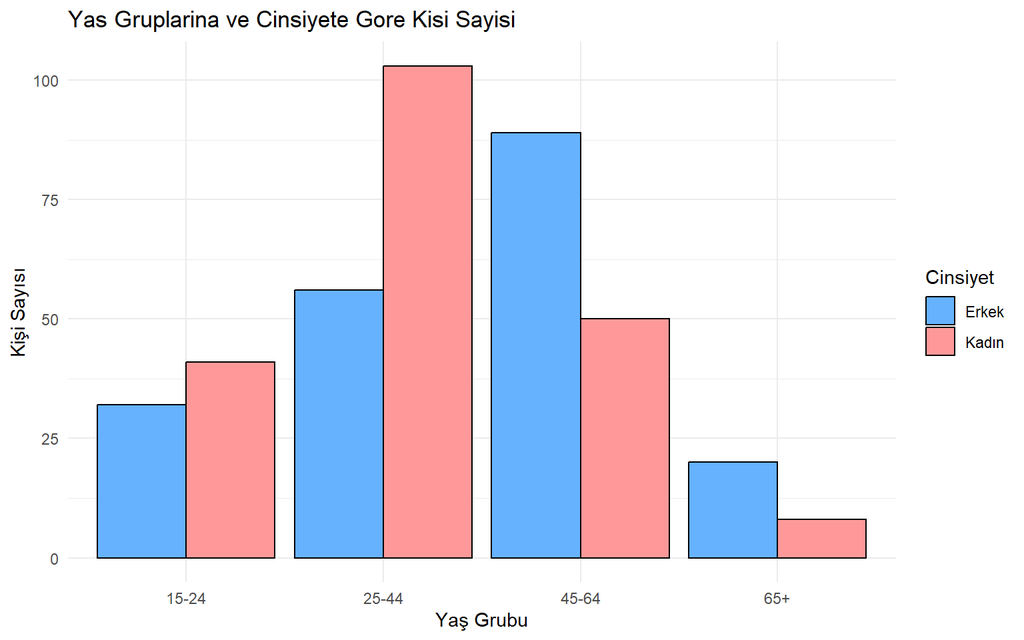

```r
data_temiz %>%
  count(age, gender) %>%
  ggplot(aes(x = age, y = n, fill = gender)) +
  geom_col(position = "dodge", color = "black") +
  scale_fill_manual(values = c("Kadın" = "#FF9999", "Erkek" = "#66B2FF")) +
  theme_minimal() +
  labs(title = "Yas Gruplarina ve Cinsiyete Gore Kisi Sayisi",
       x = "Yaş Grubu",
       y = "Kişi Sayısı",
       fill = "Cinsiyet")
```

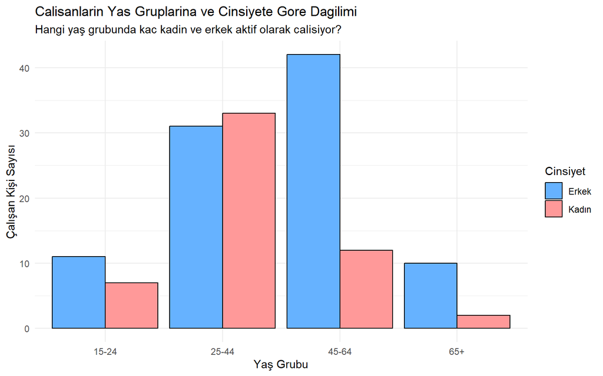

```r
data_temiz %>%
  filter(empstat == "Calisiyor") %>%
  ggplot(aes(x = age, fill = gender)) +
  geom_bar(position = "dodge", color = "black") +
  scale_fill_manual(values = c("Kadın" = "#FF9999", "Erkek" = "#66B2FF")) +
  theme_minimal() +
  labs(title = "Calisanlarin Yas Gruplarina ve Cinsiyete Gore Dagilimi",
       subtitle = "Hangi yaş grubunda kac kadin ve erkek aktif olarak calisiyor?",
       x = "Yaş Grubu",
       y = "Çalışan Kişi Sayısı",
       fill = "Cinsiyet")
```

```r
data_temiz %>%
      filter(empstat != "Calisiyor") %>%
    filter(age=="25-44" | age=="45-64") %>%
  count(gender,age,marital)
```

```
##    gender   age marital  n
## 1   Erkek 25-44   Bekar 10
## 2   Erkek 25-44    Evli 14
## 3   Erkek 25-44     Dul  1
## 4   Erkek 45-64   Bekar  5
## 5   Erkek 45-64    Evli 39
## 6   Erkek 45-64 Bosandi  2
## 7   Erkek 45-64     Dul  1
## 8   Kadın 25-44   Bekar  9
## 9   Kadın 25-44    Evli 57
## 10  Kadın 25-44 Bosandi  4
## 11  Kadın 45-64   Bekar  2
## 12  Kadın 45-64    Evli 27
## 13  Kadın 45-64 Bosandi  5
## 14  Kadın 45-64     Dul  4
```

# 4.Lojistik Regresyon Modeli

Bu kısımda lojistik regresyon modeli aracılığı ile çalışma durumunun diğer değişkenlere göre nasıl etkilendiğini göreceğiz.

Bu kod bloğu ile calisiyor olarak görünmeyenleri binary modele yani 0 1 şekline getiriyoruz ki modelimiz çalışsın.

##Modelin Kurulumu

```r
data_model <- data_temiz %>%
 filter(empstat != "Diger") %>%
  mutate(hedef_calisiyor = as.integer(empstat == "Calisiyor"))

istihdam_modeli <- glm(hedef_calisiyor ~ gender + educ + age + marital + degurba,
                       data = data_model,
                       family = "binomial")
summary(istihdam_modeli)
```

```
##
## Call:
## glm(formula = hedef_calisiyor ~ gender + educ + age + marital +
##     degurba, family = "binomial", data = data_model)
##
## Coefficients:
##                      Estimate Std. Error z value Pr(>|z|)
## (Intercept)          -0.21954    0.45479  -0.483  0.62929
## genderKadın          -1.01369    0.25488  -3.977 6.98e-05 ***
## educ.L                2.36729    0.92193   2.568  0.01024 *
## educ.Q               -0.79560    0.87098  -0.913  0.36100
## educ.C                1.19595    0.74085   1.614  0.10647
## educ^4                0.05012    0.61003   0.082  0.93452
## educ^5                0.28503    0.47557   0.599  0.54894
## educ^6               -0.20208    0.35834  -0.564  0.57280
## educ^7                0.56124    0.31356   1.790  0.07347 .
## age25-44              1.33521    0.43241   3.088  0.00202 **
## age45-64              0.84225    0.47147   1.786  0.07403 .
## age65+                0.99944    0.62677   1.595  0.11080
## maritalEvli          -0.05796    0.34913  -0.166  0.86815
## maritalBosandi       -0.57413    0.74269  -0.773  0.43949
## maritalDul            0.53501    0.80157   0.667  0.50448
## degurbaOrtaYogunKent -0.37039    0.44432  -0.834  0.40450
## degurbaYogunKent     -1.06939    0.33956  -3.149  0.00164 **
## ---
## Signif. codes:  0 '***' 0.001 '**' 0.01 '*' 0.05 '.' 0.1 ' ' 1
##
## (Dispersion parameter for binomial family taken to be 1)
##
##     Null deviance: 505.09  on 376  degrees of freedom
## Residual deviance: 450.05  on 360  degrees of freedom
## AIC: 484.05
##
## Number of Fisher Scoring iterations: 5
```

Bu tablodaki bulgulara bakarak yaptığım çıkarımlardan bazılarını maddeler halinde eklemek istiyorum.

## Modelin anlamlandırılması

Başlamadan önce en sağda bulunan sütundaki değerlerin yanında yıldız bulunuyor ise bu demek oluyor ki sonuç güvenilirdir. Estimate (Katsayı) değeri + ise çalışma ihtimali artar - ise düşer. Şimdi çıkarımlara geçelim.

2.25-44 yaş aralığına baktığımız zaman çalışma oranının gayet yüksek olduğu gözüküyor. Yani 25-44 yaş aralığı çalışma ihtimali olarak en yüksek aralık.

3.Ne kadar aksini düşünmüş olsam da Kırsalda yaşayanlara kıyasla,yoğun kentte yaşamak genel çalışma ihtimalini düşürüyor.

4.Burada eğitim seviyesini sıraladığımız için model eğitim seviyesini Lineer(x^1), Quadratik(x^2) vb. olarak hesaplamıştır. Yani ğitim seviyesindeki her bir basamaklık artış, çalışma ihtimalini lineer olarak arttırmaktadır.

5. Medeni duruma baktığımızda ise herhangi bir anlamlı ifade göremediğimizden dolayı. Evli ve ya Bekar olmanın bu örneklem üzerinde bir etkisi olmadığını söyleyebiliriz.